# SmartControlsAssignment

```python
import pandas as pd
import numpy as np
import matplotlib.pyplot as plt
import seaborn as sns
import pylab as pl
from sklearn.model_selection import train_test_split
import pickle
import json
import ast
from sklearn.linear_model import LogisticRegression
from joblib import load, dump
from sklearn.metrics import accuracy_score, f1_score, confusion_matrix, recall_score, roc_auc_score
from sklearn.metrics import classification_report
from sklearn.metrics import confusion_matrix
from sklearn.ensemble import RandomForestClassifier
from sklearn import preprocessing
from sklearn.feature_selection import SelectFromModel
from sklearn.utils import resample
import xgboost as xgb
from sklearn.neural_network import MLPClassifier
from sklearn.svm import SVC
from sklearn.feature_selection import SelectFpr,SelectFwe,VarianceThreshold,f_classif,chi2
```

```python
file_name = 'dataset_for_product_grade.csv'
data = pd.read_csv(file_name)
data.head()
```

|  | BATCHNO | SNO | BALE | STARTTIME | ENDTIME | GRADE | T1 | T2 | T3 | T4 | ... | T19 | T20 | T21 | T22 | T23 | T24 | T25 | T26 | T27 | T28 |
| --- | --- | --- | --- | --- | --- | --- | --- | --- | --- | --- | --- | --- | --- | --- | --- | --- | --- | --- | --- | --- | --- |
| 0 | 193089 | 1 | 1 | 3/26/2019 12:44 | 3/26/2019 13:05 | B+ | 0.5626 | 0.3742 | 0.5114 | 0.5265 | ... | 0.3801 | 0.5062 | 0.3914 | 0.3180 | 0.3652 | 0.3851 | 0.3397 | 0.3904 | 0.3077 | 0.2208 |
| 1 | 193089 | 6 | 9 | 3/26/2019 13:22 | 3/26/2019 13:25 | A | 0.2116 | 0.2835 | 0.2963 | 0.3037 | ... | 0.2917 | 0.2111 | 0.3270 | 0.2500 | 0.2889 | 0.2667 | 0.3167 | 0.3185 | 0.3188 | 0.2593 |
| 2 | 193089 | 8 | 11 | 3/26/2019 13:26 | 3/26/2019 13:28 | A | 0.2381 | 0.2083 | 0.2381 | 0.2381 | ... | 0.2333 | 0.2321 | 0.2372 | 0.2357 | 0.2353 | 0.2368 | 0.2381 | 0.2500 | 0.2381 | 0.2500 |
| 3 | 193089 | 9 | 12 | 3/26/2019 13:28 | 3/26/2019 13:31 | A | 0.2301 | 0.2646 | 0.2963 | 0.2963 | ... | 0.0000 | 0.3167 | 0.3256 | 0.3231 | 0.3111 | 0.3286 | 0.3232 | 0.2889 | 0.2000 | 0.2222 |
| 4 | 193089 | 11 | 14 | 3/26/2019 13:32 | 3/26/2019 13:36 | A | 0.2299 | 0.1852 | 0.3111 | 0.3111 | ... | 0.3667 | 0.2146 | 0.2593 | 0.3148 | 0.3148 | 0.3267 | 0.3185 | 0.3167 | 0.2727 | 0.0000 |

5 rows × 34 columns

```python
print(data.shape)
```

```
(81999, 34)
```

```python
print(data.info())
data = data.drop(['BATCHNO','SNO','BALE','STARTTIME','ENDTIME'], axis = 1)
print(data.info())
```

```
<class 'pandas.core.frame.DataFrame'>
RangeIndex: 81999 entries, 0 to 81998
Data columns (total 34 columns):
BATCHNO      81999 non-null int64
SNO          81999 non-null int64
BALE         81999 non-null int64
STARTTIME    81999 non-null object
ENDTIME      81999 non-null object
GRADE        81999 non-null object
T1           81999 non-null float64
T2           81999 non-null float64
T3           81999 non-null float64
T4           81999 non-null float64
T5           81999 non-null float64
T6           81999 non-null float64
T7           81999 non-null float64
T8           81999 non-null float64
T9           81999 non-null float64
T10          81999 non-null float64
T11          81999 non-null float64
T12          81999 non-null float64
T13          81999 non-null float64
T14          81999 non-null float64
T15          81999 non-null float64
T16          81999 non-null float64
T17          81999 non-null float64
T18          81999 non-null float64
T19          81999 non-null float64
T20          81999 non-null float64
T21          81999 non-null float64
T22          81999 non-null float64
T23          81999 non-null float64
T24          81999 non-null float64
T25          81999 non-null float64
T26          81999 non-null float64
T27          81999 non-null float64
T28          81999 non-null float64
dtypes: float64(28), int64(3), object(3)
memory usage: 21.3+ MB
None
```

[output cut: 20 more lines]

```
T17      81999 non-null float64
T18      81999 non-null float64
T19      81999 non-null float64
T20      81999 non-null float64
T21      81999 non-null float64
T22      81999 non-null float64
T23      81999 non-null float64
T24      81999 non-null float64
T25      81999 non-null float64
T26      81999 non-null float64
T27      81999 non-null float64
T28      81999 non-null float64
dtypes: float64(28), object(1)
memory usage: 18.1+ MB
None
```

### We have four types of Gardes in the dataset

```python
print(data['GRADE'].unique())
```

```
['B+' 'A' 'C' 'B']
```

```python
print(data.groupby('GRADE').size())
```

```
GRADE
A     80220
B       736
B+      180
C       863
dtype: int64
```

# Visualization

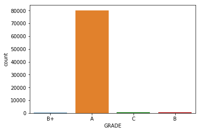

```python
sns.countplot(data['GRADE'],label="Count")
plt.show()
```

#### This data is imbalanced data so be have to balance it before appling any prediction model.

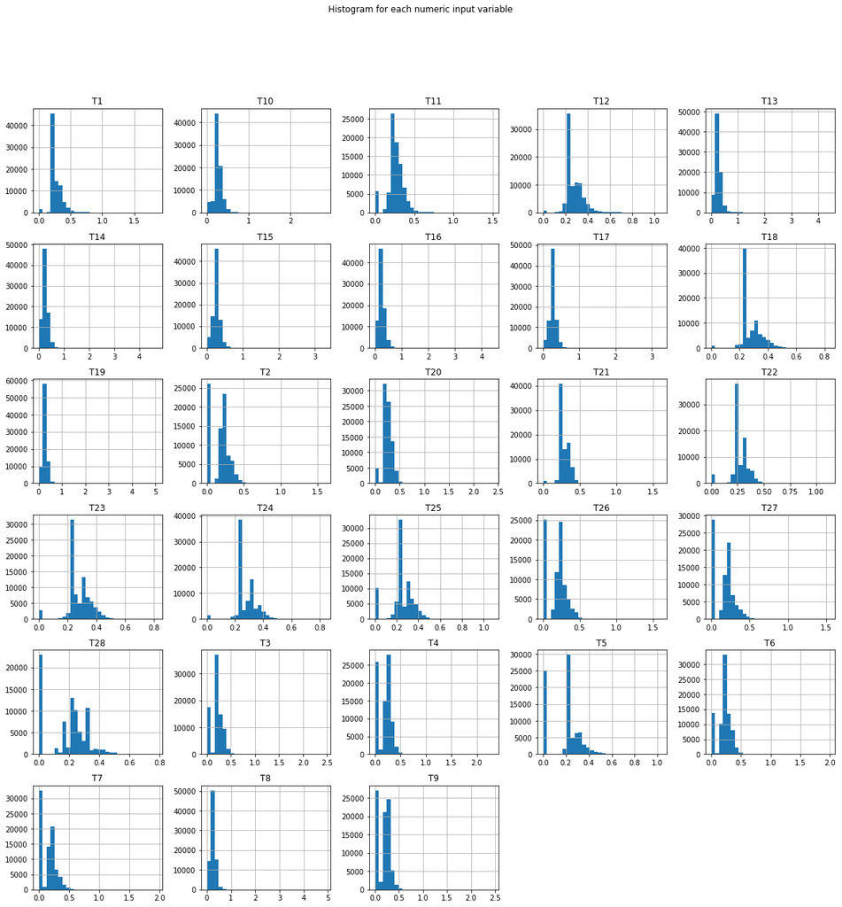

```python
data.drop(['GRADE'], axis = 1).hist(bins=30, figsize=(20,20))
pl.suptitle("Histogram for each numeric input variable")
plt.savefig('Geade_hist')
plt.show()
```

# Statistical Summary

```python
pd.DataFrame(data.describe())
```

|  | T1 | T2 | T3 | T4 | T5 | T6 | T7 | T8 | T9 | T10 | ... | T19 | T20 | T21 | T22 | T23 | T24 | T25 | T26 | T27 | T28 |
| --- | --- | --- | --- | --- | --- | --- | --- | --- | --- | --- | --- | --- | --- | --- | --- | --- | --- | --- | --- | --- | --- |
| count | 81999.000000 | 81999.000000 | 81999.000000 | 81999.000000 | 81999.000000 | 81999.000000 | 81999.000000 | 81999.000000 | 81999.000000 | 81999.000000 | ... | 81999.000000 | 81999.000000 | 81999.000000 | 81999.000000 | 81999.000000 | 81999.000000 | 81999.000000 | 81999.000000 | 81999.000000 | 81999.000000 |
| mean | 0.271941 | 0.172730 | 0.207635 | 0.174635 | 0.191675 | 0.219272 | 0.147270 | 0.240879 | 0.171310 | 0.258354 | ... | 0.255141 | 0.262277 | 0.282018 | 0.270004 | 0.277052 | 0.279153 | 0.243459 | 0.181683 | 0.166488 | 0.189723 |
| std | 0.078487 | 0.133757 | 0.130888 | 0.134800 | 0.139210 | 0.119652 | 0.137883 | 0.141609 | 0.136361 | 0.098970 | ... | 0.117832 | 0.091762 | 0.066624 | 0.080842 | 0.079500 | 0.068941 | 0.109226 | 0.134566 | 0.135574 | 0.136622 |
| min | 0.000000 | 0.000000 | 0.000000 | 0.000000 | 0.000000 | 0.000000 | 0.000000 | 0.000000 | 0.000000 | 0.000000 | ... | 0.000000 | 0.000000 | 0.000000 | 0.000000 | 0.000000 | 0.000000 | 0.000000 | 0.000000 | 0.000000 | 0.000000 |
| 25% | 0.235700 | 0.000000 | 0.166700 | 0.000000 | 0.000000 | 0.185200 | 0.000000 | 0.192600 | 0.000000 | 0.219000 | ... | 0.215600 | 0.233300 | 0.235700 | 0.234700 | 0.235300 | 0.235300 | 0.232100 | 0.000000 | 0.000000 | 0.000000 |
| 50% | 0.238100 | 0.208300 | 0.238100 | 0.222200 | 0.235800 | 0.238100 | 0.185200 | 0.245800 | 0.200000 | 0.250000 | ... | 0.250000 | 0.250000 | 0.250000 | 0.250000 | 0.250000 | 0.250000 | 0.250000 | 0.230800 | 0.200000 | 0.222200 |
| 75% | 0.308600 | 0.250000 | 0.277800 | 0.250000 | 0.274500 | 0.284700 | 0.238100 | 0.311100 | 0.250000 | 0.306700 | ... | 0.311100 | 0.309300 | 0.325900 | 0.319200 | 0.325600 | 0.323500 | 0.311100 | 0.250000 | 0.250000 | 0.277800 |
| max | 1.850000 | 1.593600 | 2.441100 | 2.308900 | 1.026400 | 1.980600 | 1.943000 | 4.858600 | 2.449200 | 2.815700 | ... | 5.038000 | 2.383800 | 1.601100 | 1.119500 | 0.816600 | 0.834300 | 1.080300 | 1.607000 | 1.532700 | 0.776500 |

8 rows × 28 columns

#### We can see that the numerical values do not have the same scale. We have to apply scaling to the test set that we computed for the training set.

## The Problem with Imbalanced Classes

Most machine learning algorithms work best when the number of samples in each class are about equal. This is because most algorithms are designed to maximize accuracy and reduce error.

## The Problem with Accuracy

```python
def check(data):
    y = [1 if i=='A' else 0 for i in np.array(data['GRADE'])]
    print('Percentage of Grade A quality product is: '+ str((y.count(1)/len(y))*100))
    print('Percentage of other quality product is: '+ str((y.count(0)/len(y))*100))
    return y

y = check(data)
```

```
Percentage of Grade A quality product is: 97.83046134708961
Percentage of other quality product is: 2.1695386529104015
```

###### If i predict all the products are Grade A quality still i will get the

#### Accuary of 97.83%.

```python
def save_model(name, clf, X_train, y_train):
    model = clf.fit(X_train, y_train)
    try:
        val = load('model.joblib')
        val[name] = model
        dump(val, 'model.joblib')
    except:
        ddict = {}
        ddict[name] = model
        dump(ddict, 'model.joblib')
    return model

def load_model(name, clf, X_train, y_train):
    try:
        val = load('model.joblib')
        if name in val.keys():
            return val[name]
        else:
            model1 = save_model(name, clf, X_train, y_train)
            return model1
    except:
        model1 = save_model(name, clf, X_train, y_train)
        return model1
```

```python
BalanceFunction = ''
X_train, X_test, y_train, y_test = train_test_split(data.drop('GRADE', axis=1), y, random_state=0)
model = 'logistic'
clf = LogisticRegression(solver='liblinear')
logistic = load_model(model+'@'+BalanceFunction, clf, X_train, y_train)
# Predict on training set
lr_pred = logistic.predict(X_test)

# Checking accuracy
print('accuracy of ' + model + ' model is: '+str(accuracy_score(y_test, lr_pred)*100) + '%')
print('_'*100)
print('')

# Checking unique values
print('Checking unique values')
predictions = pd.DataFrame(lr_pred)
predictions[0].value_counts()
```

```
accuracy of logistic model is: 97.55121951219512%
____________________________________________________________________________________________________

Checking unique values
```

```
1    20479
0       21
Name: 0, dtype: int64
```

**Maybe not surprisingly, our accuracy score decreased as compared to the dummy classifier above. This tells us that either we did something wrong in our logistic regression model, or that accuracy might not be our best option for measuring performance.**

Let’s take a look at some popular methods for dealing with class imbalance.</b>

# Change the performance metric

As we saw above, accuracy is not the best metric to use when evaluating imbalanced datasets as it can be very misleading. Metrics that can provide better insight include:

```
Confusion Matrix: a table showing correct predictions and types of incorrect predictions.

Precision: the number of true positives divided by all positive predictions. Precision is also called Positive Predictive Value. It is a measure of a classifier’s exactness. Low precision indicates a high number of false positives.

Recall: the number of true positives divided by the number of positive values in the test data. Recall is also called Sensitivity or the True Positive Rate. It is a measure of a classifier’s completeness. Low recall indicates a high number of false negatives.

F1 Score: the weighted average of precision and recall.
```

Let’s see what happens when we apply these F1 and recall scores to our logistic regression from above.

```python
print('confusion matrix')
print(confusion_matrix(y_test, lr_pred))
print('-'*100)
print(classification_report(y_test, lr_pred))
```

```
confusion matrix
[[    8   489]
 [   13 19990]]
----------------------------------------------------------------------------------------------------
              precision    recall  f1-score   support

           0       0.38      0.02      0.03       497
           1       0.98      1.00      0.99     20003

   micro avg       0.98      0.98      0.98     20500
   macro avg       0.68      0.51      0.51     20500
weighted avg       0.96      0.98      0.96     20500
```

[figure not shown]

**True Positives (TP)** - These are the correctly predicted positive values which means that the value of actual class is yes and the value of predicted class is also yes. E.g. if actual class value indicates that this passenger survived and predicted class tells you the same thing.

**True Negatives (TN)** - These are the correctly predicted negative values which means that the value of actual class is no and value of predicted class is also no. E.g. if actual class says this passenger did not survive and predicted class tells you the same thing.

**False Positives (FP)** – When actual class is no and predicted class is yes. E.g. if actual class says this passenger did not survive but predicted class tells you that this passenger will survive.

**False Negatives (FN)** – When actual class is yes but predicted class in no. E.g. if actual class value indicates that this passenger survived and predicted class tells you that passenger will die.

# Change the algorithm

While in every machine learning problem, it’s a good rule of thumb to try a variety of algorithms, it can be especially beneficial with imbalanced datasets. Decision trees frequently perform well on imbalanced data. They work by learning a hierarchy of if/else questions and this can force both classes to be addressed.

```python
def evalute(y_test, pred):
    print('accuracy score: '+ str(accuracy_score(y_test, pred)))
    print('-'*100)
    print('confusion matrix')
    print(confusion_matrix(y_test, pred))
    print('-'*100)
    print(classification_report(y_test, pred))
#     print('AucRoc score: ' + str(roc_auc_score(y_test,pred) ))
```

```python
# BalanceFunction,model
BalanceFunction = ''
model = 'RandomForest'
rfc = RandomForestClassifier(n_estimators=100,random_state=0,n_jobs=-1)
rndm = load_model(model+'@'+BalanceFunction, rfc, X_train, y_train)
evalute(y_test, rndm.predict(X_test))
```

[output not shown]

**both F1 and recall have increased as compared to logistic regression! It appears that for this specific problem, random forest may be a better choice of model.**

# Create Training and Test Sets and Apply Scaling

```python
encoder = preprocessing.LabelEncoder().fit(np.array(data['GRADE']))
y = encoder.transform(data['GRADE'])
X = data.drop(['GRADE'], axis=1)
def scaling(X, y):
    X_train, X_test, y_train, y_test = train_test_split(X, y, random_state=123)
    # from sklearn.preprocessing import MinMaxScaler
    scaler = preprocessing.MinMaxScaler()
    X_train = scaler.fit_transform(X_train)
    X_test = scaler.transform(X_test)
    return X_train, X_test, y_train, y_test
```

# Feature Selection

```python
def selectfpr(X, y):
    print('Shape of Original input dataset is: ',np.shape(X))
    smf = SelectFpr(chi2, alpha=0.001).fit_transform(X, y)
    print('Shape of Transformed input dataset is: ',np.shape(smf))
    return smf

def selectfwe(X, y):
    print('Shape of Original input dataset is: ',np.shape(X))
    smf = SelectFwe(chi2, alpha=0.01).fit_transform(X, y)
    print('Shape of Transformed input dataset is: ',np.shape(smf))
    return smf

def variance_threshold(X,y):
    print('Shape of Original input dataset is: ',np.shape(X))
    smf = VarianceThreshold(threshold=0.01).fit_transform(X)
    print('Shape of Transformed input dataset is: ',np.shape(smf))
    return smf
```

# Handling imbalanced classes

### 1. Up-sample Minority Class

Up-sampling is the process of randomly duplicating observations from the minority class in order to reinforce its signal. There are several heuristics for doing so, but the most common way is to simply resample with replacement.

Some steps:

```
1. First, we'll separate observations from each class into different DataFrames.
2. Next, we'll resample the minority class with replacement, setting the number of samples to match that of the majority class.
3. Finally, we'll combine the up-sampled minority class DataFrame with the original majority class DataFrame.
```

```python
def upSample(X, y, a=1, b=1):
    print('..UpSampling on input dataset')
    X = pd.DataFrame(X)
    X['GRADE'] = y
    # Separate majority and minority classes
    df_majority = X[X['GRADE']==0]
    df_minority1 = X[X['GRADE']==1]
    df_minority2 = X[X['GRADE']==2]
    df_minority3 = X[X['GRADE']==3]

    # Upsample minority class
    df_minority_upsampled1 = resample(df_minority1,
                                     replace=True,     # sample with replacement
                                     n_samples=np.shape(df_majority)[0]*a//b,    # to match majority class
                                     random_state=123) # reproducible results
    df_minority_upsampled2 = resample(df_minority2,
                                     replace=True,     # sample with replacement
                                     n_samples=np.shape(df_majority)[0]*a//b,    # to match majority class
                                     random_state=123) # reproducible results
    df_minority_upsampled3 = resample(df_minority3,
                                     replace=True,     # sample with replacement
                                     n_samples=np.shape(df_majority)[0]*a//b,    # to match majority class
                                     random_state=123) # reproducible results
    # Combine minority class with downsampled majority class
    df_upsampled = pd.concat([df_majority, df_minority_upsampled1,df_minority_upsampled2,df_minority_upsampled3])
    print('new class counts after up sampling')
    print(df_upsampled.GRADE.value_counts())
    b = df_upsampled['GRADE']
    a = df_upsampled.drop(['GRADE'], axis = 1)
    return a,b

def upSample1(X, y):
    print('..UpSampling on input dataset')
    X = pd.DataFrame(X)
    X['GRADE'] = y
    # Separate majority and minority classes
    df_majority = X[X['GRADE']==0]
    df_minority = X[X['GRADE']==1]

    # Upsample minority class
    df_minority_upsampled = resample(df_minority,
                                     replace=True,     # sample with replacement
                                     n_samples=np.shape(df_majority)[0],    # to match majority class
                                     random_state=123) # reproducible results
    # Combine minority class with downsampled majority class
    df_upsampled = pd.concat([df_majority, df_minority_upsampled])
    print('new class counts after up sampling')
    print(df_upsampled.GRADE.value_counts())
    b = df_upsampled['GRADE']
    a = df_upsampled.drop(['GRADE'], axis = 1)
    return a,b
```

### 2. Down-sample Majority Class

Down-sampling involves randomly removing observations from the majority class to prevent its signal from dominating the learning algorithm. The most common heuristic for doing so is resampling without replacement.

The process is similar to that of up-sampling. Here are the steps:

```
1. First, we'll separate observations from each class into different DataFrames.
2. Next, we'll resample the majority class without replacement, setting the number of samples to match that of the minority class.
3. Finally, we'll combine the down-sampled majority class DataFrame with the original minority class DataFrame.
```

```python
def downSample(X,y):
    print('..DownSampling on input dataset')
    # Separate majority and minority classes
    X = pd.DataFrame(X)
    X['GRADE'] = y
    df_minority = X[X['GRADE']==2]
    df_majority1 = X[X['GRADE']==0]
    df_majority2 = X[X['GRADE']==1]
    df_majority3 = X[X['GRADE']==3]
    val = np.shape(df_minority)[0]

    # Upsample minority class
    df_majority_upsampled1 = resample(df_majority1,
                                     replace=False,     # sample with replacement
                                     n_samples=val,    # to match majority class
                                     random_state=123) # reproducible results
    df_majority_upsampled2 = resample(df_majority2,
                                     replace=False,     # sample with replacement
                                     n_samples=val,    # to match majority class
                                     random_state=123) # reproducible results
    df_majority_upsampled3 = resample(df_majority3,
                                     replace=False,     # sample with replacement
                                     n_samples=val,    # to match majority class
                                     random_state=123) # reproducible results
    # Combine minority class with downsampled majority class
    df_downsampled = pd.concat([df_minority, df_majority_upsampled1,df_majority_upsampled2,df_majority_upsampled3])


    # Display new class counts
    print('new class counts after down sampling')
    print(df_downsampled.GRADE.value_counts())
    b = df_downsampled['GRADE']
    a = df_downsampled.drop(['GRADE'], axis = 1)
    return a,b
```

### 3. SMOTE (Synthetic Minority Over-sampling Technique)

SMOTE is an over-sampling method. It creates synthetic samples of the minority class. We use imblearn python package to over-sample the minority classes .

```python
def smote(X,y):
    print('..UpSampling on input dataset')
    from imblearn.over_sampling import SMOTE
    X_sm, y_sm = X, y
    c = 0
    while c != 3:
        smote = SMOTE('minority')
        X_sm, y_sm = smote.fit_sample(X_sm, y_sm)
        c += 1
#     X_sm = X_sm[:,:-1]
    print('new class counts after up sampling')
    print(X_sm.shape, y_sm.shape)
    return X_sm,y_sm
```

# Pridiction Algorithms

```python
def machineLearningModel1(data):
    models = {
        'RandonForest': RandomForestClassifier(),
    #     'SVM': SVC(kernel='linear', class_weight='balanced', probability=True),
        'xgboost': xgb.XGBClassifier()
             }
    balancing_technique = {
        '': None,
        'UpSample': upSample,
        'DownSample': downSample,
        'smote': smote
    }

    counter = 0
    for i in models.keys():
        for j in balancing_technique.keys():
            encoder = preprocessing.LabelEncoder().fit(np.array(data['GRADE']))
            y = encoder.transform(data['GRADE'])
            X = data.drop(['GRADE'], axis=1)
            print(str(counter+1)+'. performing '+i+' model using '+j+' Balancing algorithm')
            if j != '':
                Xs, ys = balancing_technique[j](X, y)
            else:
                Xs, ys = X, y

            X_train, X_test, y_train, y_test = scaling(Xs, ys)

            print(X_train.shape, X_test.shape)
            model = load_model(i+'@'+j+'#'+k,models[i], X_train, y_train)
            evalute(y_test, model.predict(X_test))
            counter += 1
            print('_'*100)
            print('')
            print('')
```

```python
machineLearningModel1(data)
```

[output not shown]

```
new class counts after up sampling
3    80220
2    80220
1    80220
0    80220
Name: GRADE, dtype: int64
(240660, 28) (80220, 28)
accuracy score: 0.999800548491648
----------------------------------------------------------------------------------------------------
confusion matrix
[[20064     0     5    11]
 [    0 20081     0     0]
 [    0     0 20155     0]
 [    0     0     0 19904]]
----------------------------------------------------------------------------------------------------
              precision    recall  f1-score   support

           0       1.00      1.00      1.00     20080
           1       1.00      1.00      1.00     20081
           2       1.00      1.00      1.00     20155
           3       1.00      1.00      1.00     19904

   micro avg       1.00      1.00      1.00     80220
   macro avg       1.00      1.00      1.00     80220
weighted avg       1.00      1.00      1.00     80220

____________________________________________________________________________________________________


3. performing RandonForest model using DownSample Balancing algorithm
..DownSampling on input dataset
new class counts after down sampling
3    180
2    180
1    180
0    180
Name: GRADE, dtype: int64
(540, 28) (180, 28)
accuracy score: 0.49444444444444446
----------------------------------------------------------------------------------------------------
```

[output cut: 10 more lines]

```
           2       0.62      0.77      0.69        43
           3       0.42      0.28      0.34        50

   micro avg       0.49      0.49      0.49       180
   macro avg       0.48      0.50      0.48       180
weighted avg       0.49      0.49      0.49       180

____________________________________________________________________________________________________


4. performing RandonForest model using smote Balancing algorithm
..UpSampling on input dataset
new class counts after up sampling
(320880, 28) (320880,)
(240660, 28) (80220, 28)
```

```
accuracy score: 0.993779606083271
----------------------------------------------------------------------------------------------------
confusion matrix
[[19733    87    27   222]
 [   90 20041     1     6]
 [    0     0 20100     0]
 [   60     5     1 19847]]
----------------------------------------------------------------------------------------------------
              precision    recall  f1-score   support

           0       0.99      0.98      0.99     20069
           1       1.00      1.00      1.00     20138
           2       1.00      1.00      1.00     20100
           3       0.99      1.00      0.99     19913

   micro avg       0.99      0.99      0.99     80220
   macro avg       0.99      0.99      0.99     80220
weighted avg       0.99      0.99      0.99     80220

____________________________________________________________________________________________________


5. performing xgboost model using  Balancing algorithm
(61499, 28) (20500, 28)
accuracy score: 0.9790731707317073
----------------------------------------------------------------------------------------------------
confusion matrix
[[20049     0     1     8]
 [  197     0     0     1]
 [   48     0     0    10]
 [  164     0     0    22]]
----------------------------------------------------------------------------------------------------
              precision    recall  f1-score   support

           0       0.98      1.00      0.99     20058
           1       0.00      0.00      0.00       198
           2       0.00      0.00      0.00        58
           3       0.54      0.12      0.19       186

   micro avg       0.98      0.98      0.98     20500
   macro avg       0.38      0.28      0.30     20500
weighted avg       0.96      0.98      0.97     20500

____________________________________________________________________________________________________


6. performing xgboost model using UpSample Balancing algorithm
..UpSampling on input dataset
```

```
new class counts after up sampling
3    80220
2    80220
1    80220
0    80220
Name: GRADE, dtype: int64
(240660, 28) (80220, 28)
accuracy score: 0.7615806532036898
----------------------------------------------------------------------------------------------------
confusion matrix
[[13484  4984   274  1338]
 [ 3332 14551   649  1549]
 [    0     0 20155     0]
 [ 3683  1824  1493 12904]]
----------------------------------------------------------------------------------------------------
              precision    recall  f1-score   support

           0       0.66      0.67      0.66     20080
           1       0.68      0.72      0.70     20081
           2       0.89      1.00      0.94     20155
           3       0.82      0.65      0.72     19904

   micro avg       0.76      0.76      0.76     80220
   macro avg       0.76      0.76      0.76     80220
weighted avg       0.76      0.76      0.76     80220

____________________________________________________________________________________________________


7. performing xgboost model using DownSample Balancing algorithm
..DownSampling on input dataset
new class counts after down sampling
3    180
2    180
1    180
0    180
Name: GRADE, dtype: int64
(540, 28) (180, 28)
accuracy score: 0.5611111111111111
----------------------------------------------------------------------------------------------------
```

[output cut: 30 more lines]

```
 [    6    55 19229   810]
 [ 1736  2674  2171 13332]]
----------------------------------------------------------------------------------------------------
              precision    recall  f1-score   support

           0       0.84      0.81      0.82     20069
           1       0.76      0.79      0.78     20138
           2       0.86      0.96      0.91     20100
           3       0.75      0.67      0.71     19913

   micro avg       0.81      0.81      0.81     80220
   macro avg       0.80      0.81      0.80     80220
weighted avg       0.80      0.81      0.80     80220

____________________________________________________________________________________________________
```